# Film_data

The dataset that I gonna investigate is that of the "Tmdb dataset". This data set contains information about 10,000 movies collected from The Movie Database (TMDb), including user ratings and revenue. It has various columns including, popularity,budget,revenue,original_title,keywords,overview,runtime,genres,production_companies,release_date among many others. Looking at the dataset, some of the questions which would be interesting to answer are as follows:

1. Which genres are most popular from year to year?
2. What kinds of properties are associated with movies that have high revenues?
3. Given a movie, can I return the Movie's tagline?

Going forward from here, I shall list down my steps of cleaning the data, and applying various operations in order to arrive at a result for the above questions.

DATA EXPLORATION AND CLEANING:

Before beginning any analysis, I list down all the required libraries that are needed in my exploration and import them as follows:

```python
#importing all the neccessary libraries
import numpy as np
import csv
import pandas as pd
import pprint
import matplotlib.pyplot as plt
from wordcloud import WordCloud
from pandas import DataFrame, Series
from decimal import Decimal
```

The dataset is taken into a Panda dataframe for easy accessibility into "film_data" pd variable.

```python
film_data = pd.read_csv('tmdb-movies.csv',sep=",",low_memory=False)
```

For the sake of verifying that the data is properly imported, we check it's shape. The 21 columns represents the 21 attributes of the data, therefore we are almost certain the data is properly imported.

```python
print(film_data.shape)
```

```
(10866, 21)
```

Before I proceed, I need to be certain that the data is not missing any values, which might results in errorneous or incorrect calculations. Therefore I check for missing values in each columns of the attributes of the dataset.

```python
for df_column in film_data.columns:
    print(df_column + ": "),
    print(sum(film_data[df_column].isnull()))
```

```
id:  0
imdb_id:  10
popularity:  0
budget:  0
revenue:  0
original_title:  0
cast:  76
homepage:  7930
director:  44
tagline:  2824
keywords:  1493
overview:  4
runtime:  0
genres:  23
production_companies:  1030
release_date:  0
vote_count:  0
vote_average:  0
release_year:  0
budget_adj:  0
revenue_adj:  0
```

We can see that some of the "imdb_id" have Nan values, therefore I come up with a solution, of replacing the missing values with the corresponding "id" values. Consequently, we also change each "imdb_id" from the format "tt_number" to "number" by removing the prefixes of "tt".

```python
data = (float)(film_data['imdb_id'][0].split('t')[2])
print(type(data))
```

```
<type 'float'>
```

I try to verify the format of the "imdb_id" attribute.

```python
print(film_data['imdb_id'][0])
```

```
tt0369610
```

I further verify the fact that there are 10 "imbd_id" values with Nan values, which are replaced by the corresponding "id"

```python
a=[]
count=0
c2=0
for data in film_data['imdb_id']:
    try:
        a.append(data.split('t')[2])
        count+=1
    except:
        a.append(film_data['id'][count])
        count+=1
        c2+=1
        print(c2)
```

```
1
2
3
4
5
6
7
8
9
10
```

We assign the updated "imdb_id" into a new Series.

```python
film_data['IMDB']=a
```

```python
print(film_data['IMDB'][0])
```

```
0369610
```

We delete the row corresponding to "imdb_id" after we have updated it.

```python
del[film_data['imdb_id']]
```

We verify to see if the "IMDB" column indeed has all the values filled properly.

```python
for df_column in film_data.columns:
    print(df_column + ": "),
    print(sum(film_data[df_column].isnull()))
```

```
id:  0
popularity:  0
budget:  0
revenue:  0
original_title:  0
cast:  76
homepage:  7930
director:  44
tagline:  2824
keywords:  1493
overview:  4
runtime:  0
genres:  23
production_companies:  1030
release_date:  0
vote_count:  0
vote_average:  0
release_year:  0
budget_adj:  0
revenue_adj:  0
IMDB:  0
```

```python
film_data['IMDB']=pd.to_numeric(film_data['IMDB'],errors='ignore')
```

DATA ANALYSIS:

Question 1: What kinds of properties are associated with movies that have high revenues?

```python
list_of_numerics = ['id','IMDB','popularity','budget','revenue','runtime','vote_count','vote_average','release_year','budget_adj','revenue_adj']
```

We shall make an analysis plot for the above columns of the film_data to find relations between revenue and the other attributes. We shall include both univariate as well as multivariate analysis. I take into account values which I feel as important namely, Popularity, Budget, Revenue and Vote Count.

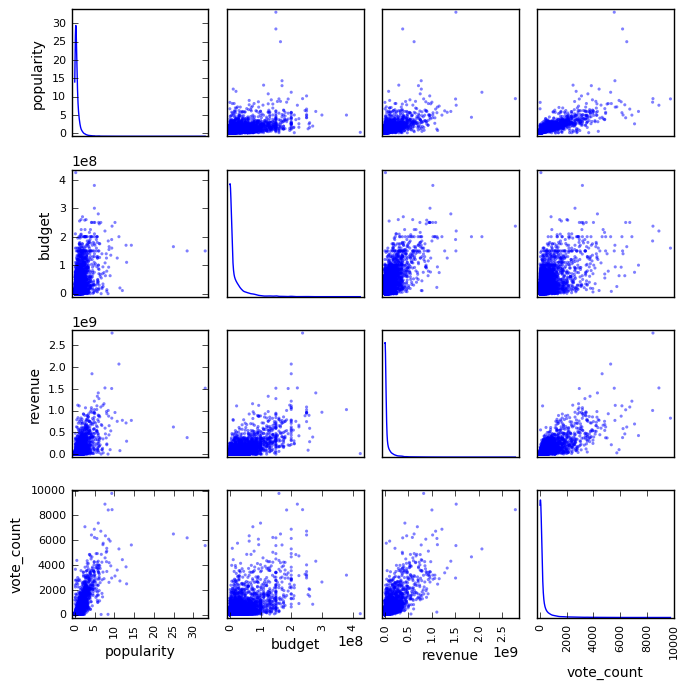

```python
pd.plotting.scatter_matrix(film_data.loc[:,["popularity","budget","revenue","vote_count"]],diagonal="kde",figsize=(7,7))
plt.tight_layout()
plt.show()
```

From the above plots we can notice that there is a positive relationship between revenue and popularity, budget and vote_count. Further more we also notice a slight positive relationship between Budget and popularity.

To reinforce the above statements, I shall take a 3D plot, namely a bubble plot between Revenue, budget and popularity.

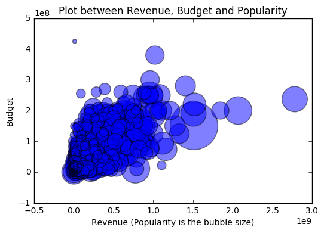

```python
x = film_data['revenue']
y = film_data['budget']
z = film_data['popularity']

# use the scatter function
plt.scatter(x, y, s=z*100, alpha=0.5)
plt.xlabel("Revenue (Popularity is the bubble size)")
plt.ylabel("Budget")
plt.title("Plot between Revenue, Budget and Popularity")
plt.show()
```

Furthermore, we shall reinforce our observation by taking numerical values of the correlations between the variables.

```python
#Loop to find out the corelation between the various numeric fields of the Film_data
for i in list_of_numerics:
    print('\n')
    for j in list_of_numerics:
        print(Decimal(film_data[i].corr(film_data[j])).quantize(Decimal('.001'))),
```

```
1.000 0.872 -0.014 -0.141 -0.099 -0.088 -0.036 -0.058 0.511 -0.189 -0.138

0.872 1.000 -0.006 -0.103 -0.067 -0.158 0.001 -0.054 0.679 -0.168 -0.125

-0.014 -0.006 1.000 0.545 0.663 0.139 0.801 0.210 0.090 0.514 0.609

-0.141 -0.103 0.545 1.000 0.735 0.191 0.633 0.081 0.116 0.969 0.623

-0.099 -0.067 0.663 0.735 1.000 0.163 0.791 0.173 0.057 0.706 0.919

-0.088 -0.158 0.139 0.191 0.163 1.000 0.163 0.157 -0.117 0.221 0.176

-0.036 0.001 0.801 0.633 0.791 0.163 1.000 0.254 0.108 0.587 0.708

-0.058 -0.054 0.210 0.081 0.173 0.157 0.254 1.000 -0.118 0.093 0.193

0.511 0.679 0.090 0.116 0.057 -0.117 0.108 -0.118 1.000 0.017 -0.066

-0.189 -0.168 0.514 0.969 0.706 0.221 0.587 0.093 0.017 1.000 0.647

-0.138 -0.125 0.609 0.623 0.919 0.176 0.708 0.193 -0.066 0.647 1.000
```

Looking at the above results for the various values of correlation between the numeric fields of the Film_data, we can devise 3 points regarding film with high revenue:

1. A high popularity is associated with high revenue, which makes sense since a higher popularity signifies more people watching the movie, therefore resulting in higher revenue.
2. A high budget is associated with high revenue, partly maybe because a high budget movie has done a lot of research and used sophisticated technology to make its film appealing to the audience. (We also notice an above average correlation between budget and popularity, thus reinforcing my view)
3. A higher revenue movie generates higher vote_count. This fact can be extending by stating the movie's popularity.

Although I have stated the above facts, it should not be confused with causation, as there are exceptions present always.

Question 2: Given a movie, can I return the Movie's tagline?

```python
## function to return the tagline of the film selected

def tagline_film(film_name):
    pos=0
    for data in film_data['original_title']:
        if(data==film_name):
            return film_data['tagline'][pos]
        pos+=1
```

```python
print(tagline_film("Star Wars: The Force Awakens"))
```

```
Every generation has a story.
```

```python
print(tagline_film("Vegas Vacation"))
```

```
This time the Griswolds are on a roll.
```

Question 3: Which genres are most popular from year to year?

```python
print(type(film_data['release_year'][1995]))
```

```
<type 'numpy.int64'>
```

```python
#function to display a bar grpah for the list of genres collected for a year
def display_bar_graph_for_genres_series(genres,release_year):
    print(genres.sort_values(ascending=False))

    genres.sort_values(ascending=False).plot.bar()
    plt.title("Popular films for the year " + str(release_year))
    plt.ylabel("Frequency")
    plt.show()
```

```python
#generating a frequency series for the list of genres in a particular year
def generate_frequency_of_movies(genres_array,release_year):
    word_count={}
    for words in genres_array:
        if(words in word_count):
            word_count[words]+=1
        else:
            word_count[words]=1

    genres = pd.Series(word_count)
    display_bar_graph_for_genres_series(genres,release_year)
```

```python
#findind the list of popular genres in a year
def popular_genre_for_given_year(release_year):
    genres_list=[]
    count=0
    c=0
    for data in film_data['release_year']:
        if(data==release_year):
            genres=film_data['genres'][count]
            try:
                for genre in genres.split('|'):
                    genres_list.append(genre)
            except:
                continue
        count+=1
    genres_array = np.array(genres_list)

    generate_frequency_of_movies(genres_array,release_year)
```

```
Drama              98
Comedy             92
Thriller           62
Action             47
Romance            45
Family             34
Crime              31
Adventure          28
Science Fiction    24
Animation          24
Horror             21
Fantasy            21
Mystery            14
Music              10
War                 5
Foreign             4
History             4
Documentary         3
Western             2
TV Movie            1
dtype: int64
```

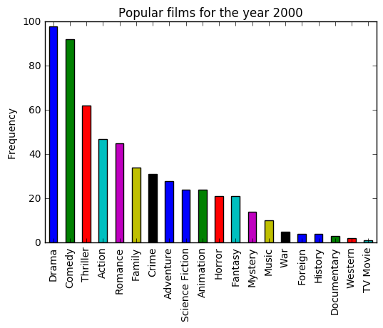

```python
popular_genre_for_given_year(2000)
```

We can clearly see that the genre Drama, Comedy and Thriller dominate the genre pool in the dataset. My further analysis on this observation is stated in the following graph below.

```
Drama              184
Thriller           124
Comedy             109
Action              90
Horror              80
Adventure           64
Science Fiction     60
Romance             41
Crime               40
Family              36
Animation           33
Fantasy             30
Mystery             26
Music               21
Documentary         14
TV Movie            12
History             11
War                  8
Western              6
dtype: int64
```

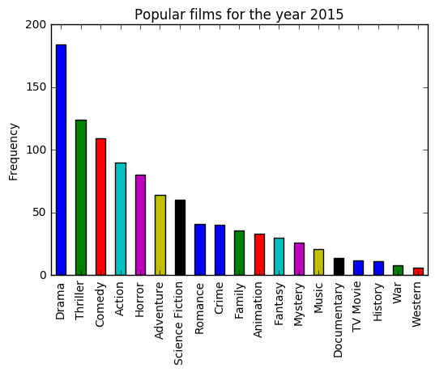

```python
popular_genre_for_given_year(2015)
```

We can view in the graphs shown above that mostly the category of drama seems to be the dominant genre in the dataset, followed by thriller and comedy. This seems appropriate as they represent a very vague term, unlike crime or history which seems to have a much more focused area. A crime can effectively also be a thriller and a drama, but the vice versa might not be true.

LIMITATIONS:

1. Some obvious problem that I encounter in the dataset is that of a common currency to state the values of revenue and budget. If films are made in different countries with different budget, we need to have a common scale in order to be able to analyze them properly.
2. The popularity of the movie is a very vague term. It does not necessarily mean that if the film was viewed by a large audience that it was more popular. Rather than that, the weekly views of the movie is a better option, as a consistent viewing every week would state more popularity than a movie which drastically dropped in views after the first week.
3. There are a few null values in the dataset, and ignoring them completely in my analysis could have resulted in a slightly skewed graphs, and incorrect predictions. An efficient way of handling null values needs to be developed.
4. There are a slighly complex and much more accurate models to analyse data, and the readers are advised to definitely look into them, as mine is a rather primitive form of analysis of a beginner who has just started out.

Wish you all the best, and keep hustling!!